# PM 566 Lab 3

Author

Uma Agarwal

```r
library(tidyverse)
library(leaflet)
library(data.table)
```

#1

```r
if (!file.exists("met_all.gz"))
  download.file(
    url = "https://raw.githubusercontent.com/USCbiostats/data-science-data/master/02_met/met_all.gz",
    destfile = "met_all.gz",
    method   = "libcurl",
    timeout  = 60
    )
met <- data.table::fread("met_all.gz")
```

#2

```r
# replace 9999 elevation w/ NA
met$elev[met$elev == 9999.0] <- NA
summary(met$elev)
```

```
   Min. 1st Qu.  Median    Mean 3rd Qu.    Max.    NA's
    -13     101     252     413     400    4113     710
```

```r
# remove -17C outlier
met <- met[ met$temp > -15, ]
met2 <- met[order(met$temp), ]
head(met2)
```

```
   USAFID  WBAN  year month   day  hour   min    lat      lon  elev wind.dir
    <int> <int> <int> <int> <int> <int> <int>  <num>    <num> <int>    <int>
1: 726764 94163  2019     8    27    11    50 44.683 -111.116  2025       NA
2: 726764 94163  2019     8    27    12    10 44.683 -111.116  2025       NA
3: 726764 94163  2019     8    27    12    30 44.683 -111.116  2025       NA
4: 726764 94163  2019     8    27    12    50 44.683 -111.116  2025       NA
5: 720411   137  2019     8    18    12    35 36.422 -105.290  2554       NA
6: 726764 94163  2019     8    26    12    30 44.683 -111.116  2025       NA
   wind.dir.qc wind.type.code wind.sp wind.sp.qc ceiling.ht ceiling.ht.qc
        <char>         <char>   <num>     <char>      <int>         <int>
1:           9              C       0          5      22000             5
2:           9              C       0          5      22000             5
3:           9              C       0          5      22000             5
4:           9              C       0          5      22000             5
5:           9              C       0          5      22000             5
```

[output cut: 17 more lines]

```r
summary(met$temp)
```

```
   Min. 1st Qu.  Median    Mean 3rd Qu.    Max.
  -3.00   19.60   23.50   23.59   27.80   56.00
```

```r
# create new variable called "week"
met[ , week := week(as.Date(paste(year, month, day, sep = "-")))]

# filter first week only
met_wk1 <- met[week == min(week, na.rm = T)]

# compute means
met_avg <- met_wk1[ , .(temp = mean(temp, na.rm = T),
                    rh = mean(rh, na.rm = T),
                    wind.sp = mean(wind.sp, na.rm = T),
                    vis.dist = mean(vis.dist, na.rm = T),
                    dew.point = mean(dew.point, na.rm = T),
                    lat = mean(lat),
                    lon = mean(lon),
                    elev = mean(elev, na.rm = T)),
                    by = "USAFID"]

# region variable
met_avg$region <- ifelse(met_avg$lon > -98 & met_avg$lat > 39.71, "north east",
                         ifelse(met_avg$lon > -98 &
                                  met_avg$lat < 39.71, "south east",
                         ifelse(met_avg$lon < -98 & met_avg$lat > 39.71,
                                "north west", "south west")))

# elev categorical variable
met_avg$elev_cat <- ifelse(met_avg$elev > 252, "high", "low")

table(met_avg$region)
```

```
north east north west south east south west
       484        146        649        296
```

```r
table(met_avg$elev_cat)
```

```
high  low
 750  825
```

#3

**Looking at the plot for dew point, the western regions have lower average dew points than the eastern regions, with the highest average dew point found in the south east. The western regions also have higher variability in dew point compared to the eastern regions.**

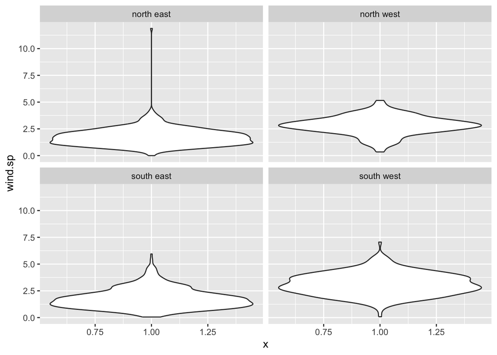

```r
# violin of wind.sp by region
met_avg %>%
  filter(!(wind.sp %in% NA)) %>% # remove NAs
ggplot() +
  geom_violin(mapping = aes(y = wind.sp, x = 1)) +
  facet_wrap(~region, nrow = 2)
```

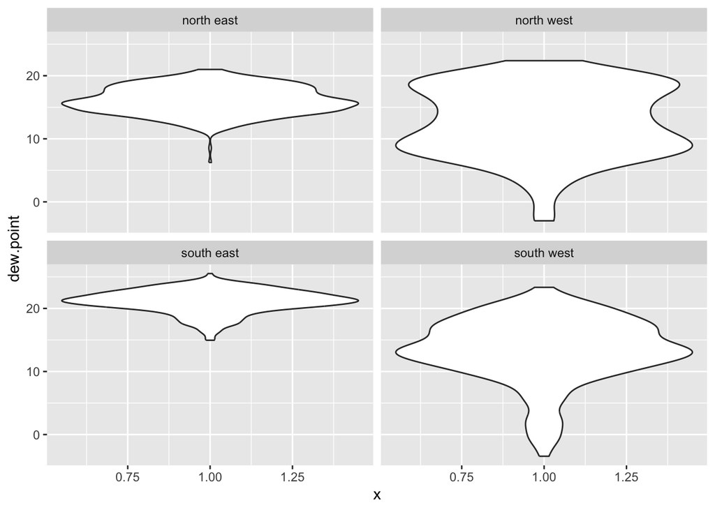

```r
# violin of dew.point by region
met_avg %>%
  filter(!(dew.point %in% NA)) %>%
ggplot() +
  geom_violin(mapping = aes(y = dew.point, x = 1)) +
  facet_wrap(~region, nrow = 2)
```

#4

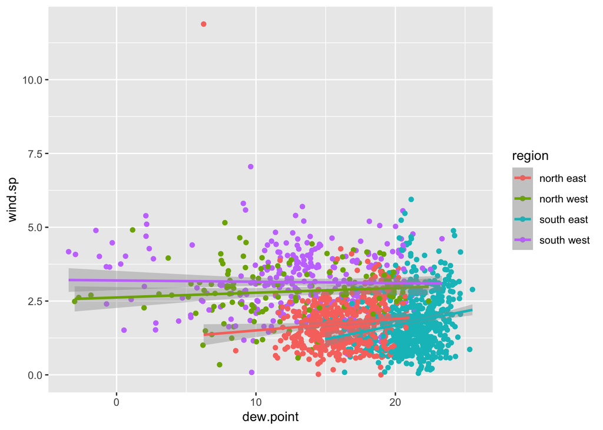

```r
# scatterplot of wind speed vs dew point by region
met_avg %>%
  filter(!(dew.point %in% NA)) %>%
ggplot(mapping = aes(x = dew.point, y = wind.sp, color = region)) +
  geom_jitter() +
  stat_smooth(method = lm) # linear regression line
```

#5

**Based on this bar plot, it appears that the weather stations categorized as being at “high” elevations are relatively evenly distributed across the four regions. However, for the weather stations categorized as being at “low” elevations, a majority of them are in the south east, with the second majority being from the the north east. Additionally, this plot also shows that most of the weather stations come from the eastern regions, and the fewest weather stations are in the north west.**

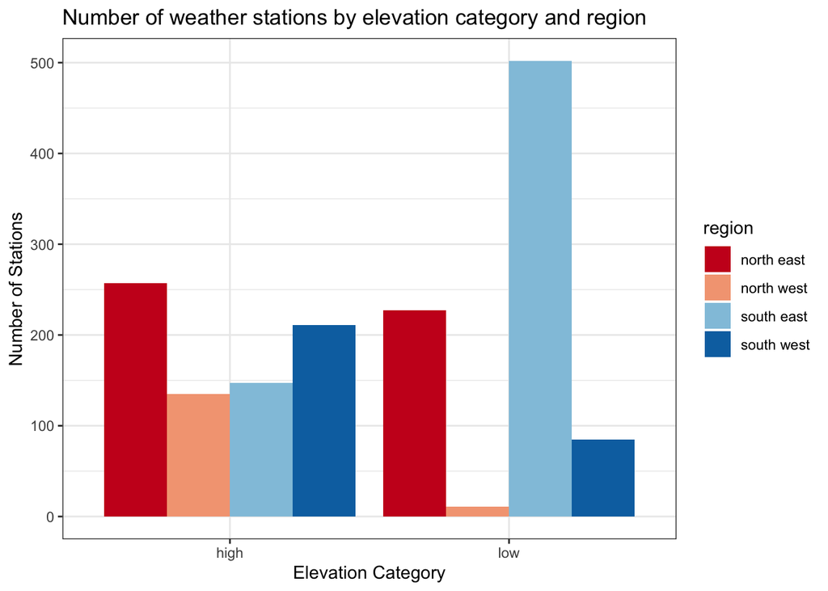

```r
# barplot of weather station by elev_cat colored by region
met_avg %>%
  filter(!(elev_cat %in% NA)) %>%
ggplot() +
  geom_bar(mapping = aes(x = elev_cat, fill = region), position = "dodge") +
  scale_fill_brewer(palette = "RdBu") +
  labs(title = "Number of weather stations by elevation category and region",
       x = "Elevation Category",
       y = "Number of Stations") +
  theme_bw()
```

#6

**Like the violin plots, the stat summary for wind speed by region shows that the eastern regions have lower average wind speed compared to the western regions. The confidence interval, shown by the error bars, appears to be relatively the same width for all four regions.**

**The stat summary for dew point by region shows that the average dew point is higher in the eastern regions than the western regions, however the confidence interval width is narrower for the eastern regions than for the western regions.** **The highest average dew point is in south east.**

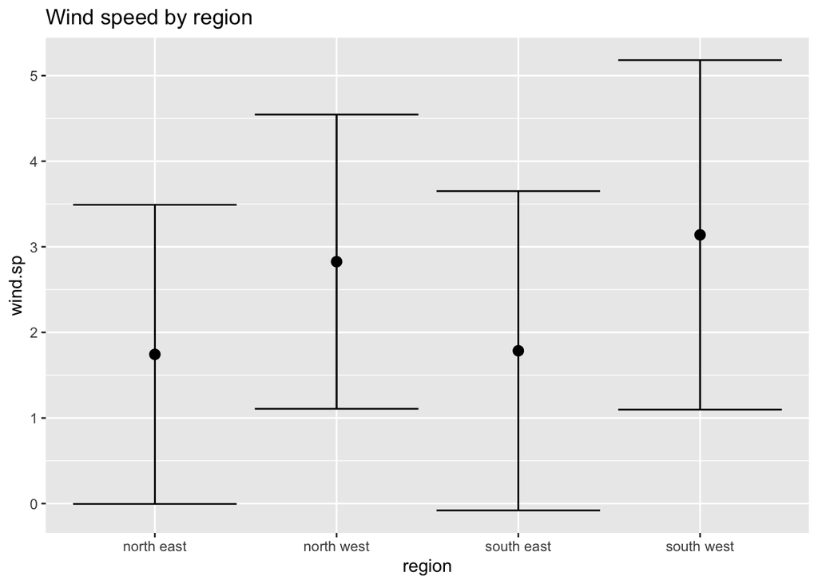

```r
# stat summary of mean wind speed by region
met_avg %>%
  filter(!is.na(dew.point) & !is.na(wind.sp)) %>%
  ggplot(mapping = aes(x = region, y = wind.sp)) +
  stat_summary(fun.data = "mean_sdl", geom = "errorbar") +
  stat_summary(fun.data = "mean_sdl") +
  labs(title = "Wind speed by region")
```

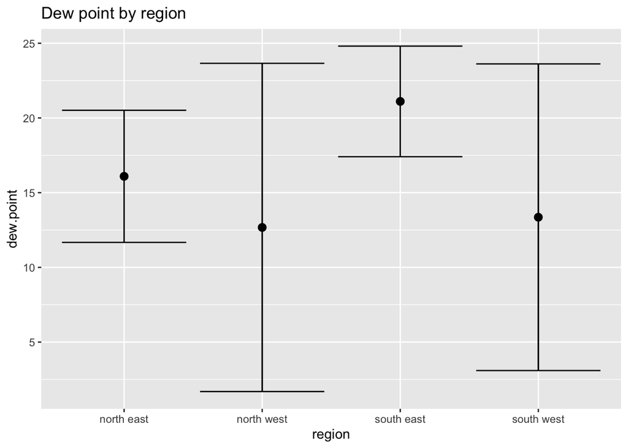

```r
# stat summary of mean dew point by region
met_avg %>%
  filter(!is.na(dew.point) & !is.na(wind.sp)) %>%
  ggplot(mapping = aes(x = region, y = dew.point)) +
  stat_summary(fun.data = "mean_sdl", geom = "errorbar") +
  stat_summary(fun.data = "mean_sdl") +
  labs(title = "Dew point by region")
```

#7

**This map shows that regions east of the Rocky Mountains tend to have the highest relative humidity**. **The relative humidity appears relatively constant, at around >70% across this region, with a slight decrease (~60% relative humidity) around the Great Lakes. For the region encompassing the Rocky Mountains, the relative humidity seems relatively constant, at around 50-60%, There is an area of decreased relative humidity (20-30%) around Nevada. Lastly, right along the entirety of the west coast, the relative humidity is much higher than the rest of the western region, at >70%.**

```r
met_avg2 <- met_avg[!is.na(rh)]
top10 <- met_avg2[rank(-rh) <= 10]

rh_pal = colorNumeric(c("yellow", "green", "blue"), domain = met_avg2$rh)

leaflet(met_avg2) %>%
  addProviderTiles("OpenStreetMap") %>%
  addCircles(lat=~lat, lng=~lon, color=~rh_pal(rh),
             label=~paste0(round(rh, 2), " rh"), opacity = 1,
             fillOpacity = 1, radius = 500) %>%
  addMarkers(lat=~lat, lng = ~lon, label=~paste0(round(rh, 2), " rh"),
             data = top10) %>%
  addLegend("bottomleft", pal = rh_pal, values = met_avg2$rh,
            title = "Relative Humidity", opacity = 1)
```

[interactive chart not shown]

#8

**Here, I used the `ggridges` package to create ridgeline plots, which is another way to show the relationship between a continuous variable and a categorical variable. I created plots to visualize temperature and relative humidity across the four regions defined earlier. The overlapping peaks and valleys of this style of plot makes it very easy to directly compare across the different categories. We are able to clearly see that the south west region has the largest variability and the highest mean temperature. Additionally, we can clearly see that the eastern regions have higher average rh compared to the western regions, while the western regions have higher variance. **

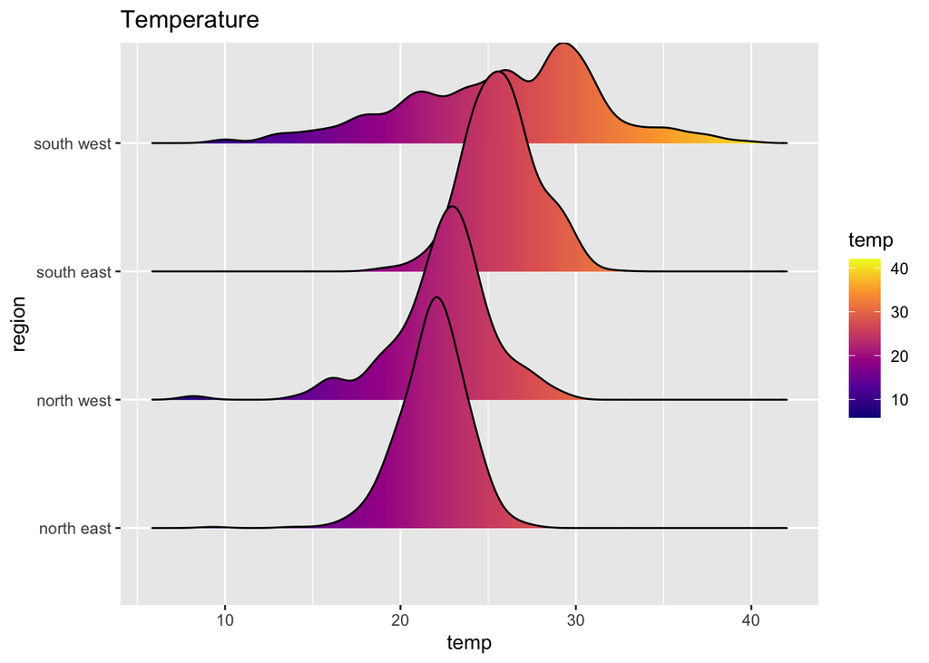

```r
library(ggridges)

met_avg %>%
  ggplot(mapping = aes(x = temp, y = region, fill = stat(x))) +
  geom_density_ridges_gradient() +
  scale_fill_viridis_c(option = "C", name = "temp") +
  labs(title = "Temperature")
```

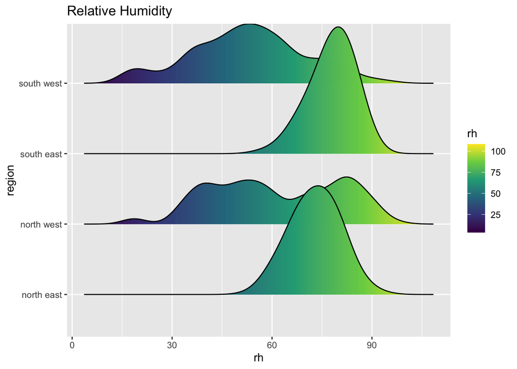

```r
met_avg %>%
  ggplot(mapping = aes(x = rh, y = region, fill = stat(x))) +
  geom_density_ridges_gradient() +
  scale_fill_viridis_c(name = "rh") +
  labs(title = "Relative Humidity")
```